# analysing overlapping calls

This notebook will pilot a bunch of methods ot analyse loud overlapping CF-FM calls. I think it should be possible to put together something which works and is not too complicated just using whatever it is that I've already coded up. Let's see.

### Idea 1: Analyse ACTUAL overlapping calls (abandoned)

This idea has been sketched out in the first part of this notebook - and isn't as straightforward as I had imagined. It might need some more work I think.

### Idea 2: Analyse call sequences Jump to Idea 2 implementation

This is idea isn't strictly in line with the main idea of the notebook - but I realised I could essentially use the fact that we have call sequences to figure out a bunch of things. The 50ms approach is too .... non-contextual I feel. Analysing entire call sequences will allow a closer contextual look eg. access to call durations, inter-pulse intervals, and duty cycle in single bat call scenarios and eg. a 'duty-cycle' also in multi-bat scenarios.

- Duty cycle estimation : I realised what I CAN do fairly easily and in a somewhat robust manner is to compare the duty cycles of the audio sequences. The duty cycle is estimated in the following manner:
  1. Load audio
  2. Determine channel with highest RMS - called the 'loudest channel'
  3. Calculate RMS profile of loudest channel with a 1ms window size
  4. Identify contiguous regions above a user-defined dBrms threshold. Discard any segments shorter than 10ms as they are unlikely to be full calls
  5. Calculate duty cycle by $\frac{\Sigma Region \:durations \geq \:threshold}{Total \:audio \:duration}$

The actual user-set threshold will be important in deciding the results of the analysis - and so it can be repeated at multiple values.

Original date of creation: 2020-11-17

Author: Thejasvi Beleyur

```python
import datetime as dt
print(f'Notebook run started at : {dt.datetime.now()}')
```

```
Notebook run started at : 2020-11-29 19:35:34.855964
```

```python
import glob
import os
import sys
import itsfm
print('itsfm version being used:',itsfm.__version__)
import numpy as np
import pandas as pd
import matplotlib.pyplot as plt
plt.rcParams['agg.path.chunksize'] = 10000
import soundfile as sf
import scipy.signal as signal
```

```
itsfm version being used: 0.1.0
```

```python
sys.path.append('../annotation_audio_analysis/measure_annot_audio/')
sys.path.append('../correct_call_annotations/')
sys.path.append('../individual_call_analysis/analysis/format_and_clean/')
```

```python
import correct_call_annotations
import ind_call_format as icf
```

```python
import correct_call_annotations.correct_call_annotations as ca2
```

```python
import inbuilt_measurement_functions as imf
```

```python
%matplotlib notebook
```

```python
folder = '/home/tbeleyur/Desktop'
filename = 'matching_annotaudio_Aditya_2018-08-19_23_31_part.wav'
audio, fs = sf.read(os.path.join(folder,filename))
```

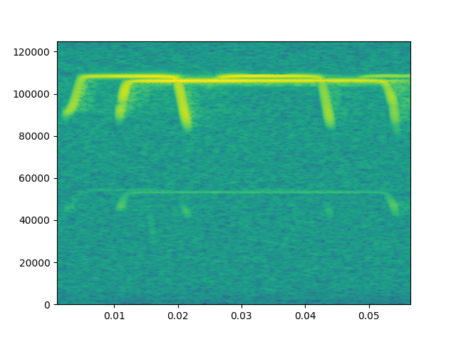

```python
plt.figure()
plt.specgram(audio,Fs=fs,NFFT=512,noverlap=511);
```

```python
kwargs = {'fs':fs,
          'nperseg':64,
          'overlap':0.8,
          'threshold':95,
          'db_range':30}

freqs = np.fft.fftfreq(kwargs['nperseg'], 1.0/fs)
non_fmfreqs = lambda X: X < 80000
fm_freqs = lambda X: np.logical_and(X>80000, X<95000)
kwargs['fm_freqs_condition']= fm_freqs
kwargs['non_signal_freqs_condition'] = non_fmfreqs
```

```python
above, fminfo, specgraminfo = imf.identify_fm_pixel_regions(audio, **kwargs )
contfm = imf.identify_continuous_fm(fminfo[1])
f,t,spec = specgraminfo
```

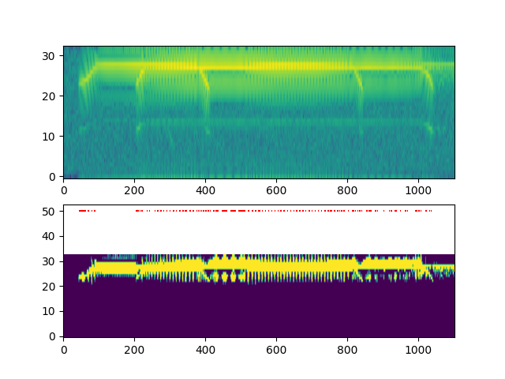

```python
plt.figure()
plt.subplot(211)
plt.imshow(imf.dB(spec), origin='lower', aspect='auto')
plt.subplot(212)
plt.imshow(above, origin='lower', aspect='auto')
for each in contfm:
    plt.hlines(50,each[0].start,each[0].stop,'r')
```

```python
from skimage.morphology import skeletonize
```

```python
binary = imf.dB(spec) > np.percentile(imf.dB(spec).flatten(), 95)


skeleton = skeletonize(binary)
```

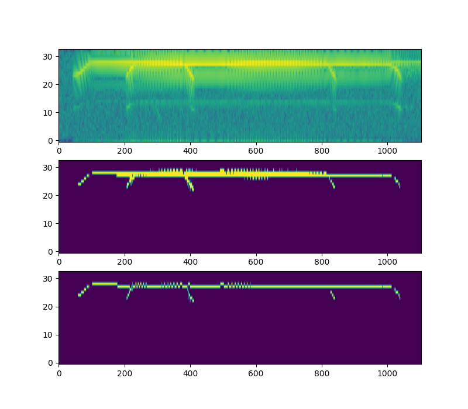

```python
plt.figure(figsize=(8,7))
plt.subplot(311)
plt.imshow(imf.dB(spec), origin='lower', aspect='auto')
plt.subplot(312)
plt.imshow(binary, origin='lower',aspect='auto')
plt.subplot(313)
plt.imshow(skeleton, origin='lower', aspect='auto')
```

## Idea 2

This section will study the call duty cycle of the bats. While the standard duty cycle measurements perhaps rely on high SNR lab-recorded or field recorded audio, we must do with what we have. The duty cycle measurements will definitely be affected by reverberation very strongly - and so I've done the same duty cycle analysis using two thresholds to define call segments - one liberal and one conservative.

```python
from itsfm.frequency_tracking import find_geq_signallevel
from itsfm.signal_processing import dB, moving_rms_edge_robust
```

```python
# all hp annotated audio are here:
verified_files = pd.read_csv('../annotation_audio_analysis/verified_annotations.csv')
random_annot = np.random.choice(verified_files['valid_annotations'],1)
```

```python
verified_w_batnums = verified_files.copy()
verified_w_batnums['annotation_id'] = verified_w_batnums['valid_annotations'].apply(lambda X: X[20:] )
```

```python
video_annot_folder = '../whole_data_analysis/annotations/corrected_HBC_video_annotations_Aditya/'
verified_w_batnums['num_bats'] = icf.get_numbats_from_annotation_id(verified_w_batnums['annotation_id'], video_annot_folder)
```

```python
verified_w_batnums
```

|  | Unnamed: 0 | valid_annotations | video_annot_id | num_bats | annotation_id |
| --- | --- | --- | --- | --- | --- |
| 0 | 0 | matching_annotaudio_Aditya_2018-08-16_21502300_18 | Aditya_2018-08-16_21502300_18 | 1 | Aditya_2018-08-16_21502300_18 |
| 1 | 1 | matching_annotaudio_Aditya_2018-08-16_21502300_20 | Aditya_2018-08-16_21502300_20 | 1 | Aditya_2018-08-16_21502300_20 |
| 2 | 2 | matching_annotaudio_Aditya_2018-08-16_21502300_22 | Aditya_2018-08-16_21502300_22 | 1 | Aditya_2018-08-16_21502300_22 |
| 3 | 3 | matching_annotaudio_Aditya_2018-08-16_21502300_24 | Aditya_2018-08-16_21502300_24 | 1 | Aditya_2018-08-16_21502300_24 |
| 4 | 4 | matching_annotaudio_Aditya_2018-08-16_21502300_25 | Aditya_2018-08-16_21502300_25 | 1 | Aditya_2018-08-16_21502300_25 |
| ... | ... | ... | ... | ... | ... |
| 409 | 430 | matching_annotaudio_Aditya_2018-08-20_0300-040... | Aditya_2018-08-20_0300-0400_84 | 1 | Aditya_2018-08-20_0300-0400_84 |
| 410 | 431 | matching_annotaudio_Aditya_2018-08-20_0300-040... | Aditya_2018-08-20_0300-0400_85 | 1 | Aditya_2018-08-20_0300-0400_85 |
| 411 | 432 | matching_annotaudio_Aditya_2018-08-20_0300-040... | Aditya_2018-08-20_0300-0400_90 | 1 | Aditya_2018-08-20_0300-0400_90 |
| 412 | 433 | matching_annotaudio_Aditya_2018-08-20_0300-040... | Aditya_2018-08-20_0300-0400_91 | 1 | Aditya_2018-08-20_0300-0400_91 |
| 413 | 434 | matching_annotaudio_Aditya_2018-08-20_0300-040... | Aditya_2018-08-20_0300-0400_92 | 1 | Aditya_2018-08-20_0300-0400_92 |

414 rows × 5 columns

```python
np.unique(verified_w_batnums['num_bats'], return_counts=True)
```

```
(array([1, 2, 3, 4]), array([302,  86,  20,   6]))
```

```python
verified_w_batnums['hp_filenames'] = verified_w_batnums['valid_annotations']+'_hp.WAV'
```

```python
bynumbats = verified_w_batnums.groupby(['num_bats'])
```

```python
def get_loudest_channel(X, channels=[0,1,2]):
    rms = np.zeros(len(channels))
    for i,each in enumerate(channels):
        rms[i] = itsfm.signal_processing.rms(X[:,each])
    loudest_channel = np.argmax(rms)
    return loudest_channel, rms
def filter_segments_by_duration(detections, fs, **kwargs):
    '''
    Parameters
    ----------
    detections: list with slices
    fs : float>0
        Frequency of sampling in Hz
    min_duration : float, optional
        The minimum duration a slice must be to be kept in the final list.
        Defaults to 0.01 s.
    Returns
    -------
    geq_minduration : list with slices
        A list with slices that are greater or equal to the minimum duration.
    '''
    durations = [float((each[0].stop-each[0].start)/fs) for each in detections]
    geq_minduration = []
    for detection, seg_durn in zip(detections,durations):
        if seg_durn >= kwargs.get('min_duration',0.01):
            geq_minduration.append(detection)
    return geq_minduration

def overall_duty_cycle(detections, audio):
    '''
    Calculates the 'ON' fraction by summing the druation of all detections and
    dividing it by the total duration of the audio.

    Parameters
    ----------
    detections: list with slices
    audio: np.array

    Returns
    -------
    overall_duty_cycle

    Notes
    -----
    This is different from the 'duty cycle' typically used in high-duty cycle
    bat echolocation eg. in Fenton, Faure, Ratcliffe 2012 (JEB)

    References
    ----------
    Fenton, M. B., Faure, P. A., & Ratcliffe, J. M. (2012). Evolution of high duty cycle echolocation in bats.
    Journal of Experimental Biology, 215(17), 2935-2944.

    '''
    total_on_samples = 0
    for each in detections:
        total_on_samples += each[0].stop-each[0].start
    try:
        assert (audio.shape[1] ==1), "Audio can only have 1 channel for duty cycle calculation"
    except:
        pass

    overall_duty_cycle = total_on_samples/float(audio.size)
    return overall_duty_cycle
```

```python
import tqdm
```

```python
from scipy import ndimage
# thanks to @matehat (https://stackoverflow.com/a/8260297/4955732)
def window_rms(a, window_size):
  a2 = np.power(a,2)
  window = np.ones(window_size)/float(window_size)
  return np.sqrt(np.convolve(a2, window, 'valid'))

def fast_find_geq_signallevel(X,fs, **kwargs):
    '''
    Modified from itsfm.frequency_tracking.find_geq_signallevel
    '''
    signal_level = kwargs.get('signal_level', -20)
    winsize = kwargs.get('window_size', int(fs*0.002))
    rec_level = dB(window_rms(X, winsize))

    ids_above_noise, num_regions = ndimage.label(rec_level>signal_level)
    if num_regions <1:
        raise ValueError('No regions above signal level found!')

    return ndimage.find_objects(ids_above_noise), rec_level
```

```python
sign_thresh = -37


def calculate_dutycycle_by_groupsize(filenamesbygroupsize, filecolname,
                                     signal_threshold, audio_folder,groupsizes=[4,3,2,1],
                                      **kwargs):
    '''
    Parameters
    ----------



    min_duration : float, optional
        Defaults to 10ms

    Returns
    -------

    '''
    dutycycle_by_groupsize = {}

    for groupsize in groupsizes:
        all_files = filenamesbygroupsize.get_group(groupsize)
        dutycycle_by_groupsize[groupsize] = []
        for each in all_files[filecolname]:
            filepath = ca2.find_file_in_folder(each, audio_folder)[0]
            if sf.info(filepath).channels>1:
                audio, fs = sf.read(filepath)
                loud_ch, channel_rms = get_loudest_channel(audio)
                audio = audio[:,loud_ch]
            else:
                audio, fs = sf.read(filepath)
            window_size = kwargs.get('window_size',int(fs*0.001))
            try:
                print('miaow')
                above_level, rms_profile = fast_find_geq_signallevel(audio, fs,
                                                                     window_size=window_size,
                                                                     signal_level=signal_threshold)
                longish_detns = filter_segments_by_duration(above_level, fs, **kwargs)
                odc = overall_duty_cycle(longish_detns, audio)
                dutycycle_by_groupsize[groupsize].append(odc)
            except:
                pass

    return dutycycle_by_groupsize
```

```python
obs_dutycyles = calculate_dutycycle_by_groupsize(bynumbats,'hp_filenames',-47,'../individual_call_analysis/hp_annotation_audio/')
```

[output not shown]

[output cut: 773 more lines]

[output not shown]

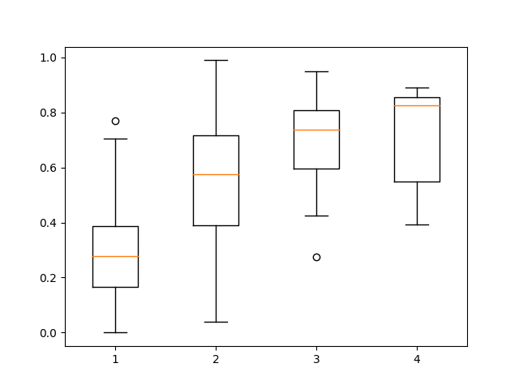

```python
plt.figure()
boxdata = []
xpos= []
for gpsize, dc in obs_dutycyles.items():
    boxdata.append(dc)
    xpos.append(gpsize)
plt.boxplot(boxdata, positions=xpos);
```

### Comparing with virtual multi bat calls!

```python
# load the raw data files behind the virtual multi bat files
virtual_source = pd.read_csv('../annotation_audio_analysis/source_files_for_virtual_multibat_audio.csv')
virtual_source['num_bats'] = virtual_source['source_single_bat_files'].apply(lambda X: len(X.split(',')))
virtual_bynumbats = virtual_source.groupby('num_bats')
```

```python
virtual_source
```

|  | Unnamed: 0 | multibat_filename | source_single_bat_files | actual_virtual_filenames | num_bats |
| --- | --- | --- | --- | --- | --- |
| 0 | 0 | matching_annotaudio_Aditya_2018-08-16_21502300... | matching_annotaudio_Aditya_2018-08-17_34_168_h... | matching_annotaudio_Aditya_2018-08-16_21502300... | 2 |
| 1 | 1 | matching_annotaudio_Aditya_2018-08-16_21502300... | matching_annotaudio_Aditya_2018-08-16_21502300... | matching_annotaudio_Aditya_2018-08-16_21502300... | 2 |
| 2 | 2 | matching_annotaudio_Aditya_2018-08-16_21502300... | matching_annotaudio_Aditya_2018-08-19_0120-020... | matching_annotaudio_Aditya_2018-08-16_21502300... | 2 |
| 3 | 3 | matching_annotaudio_Aditya_2018-08-16_21502300... | matching_annotaudio_Aditya_2018-08-17_23_193_h... | matching_annotaudio_Aditya_2018-08-16_21502300... | 2 |
| 4 | 4 | matching_annotaudio_Aditya_2018-08-16_21502300... | matching_annotaudio_Aditya_2018-08-17_12_115_h... | matching_annotaudio_Aditya_2018-08-16_21502300... | 2 |
| ... | ... | ... | ... | ... | ... |
| 95 | 95 | matching_annotaudio_Aditya_2018-08-20_0200-030... | matching_annotaudio_Aditya_2018-08-16_2324_80_... | matching_annotaudio_Aditya_2018-08-20_0200-030... | 3 |
| 96 | 96 | matching_annotaudio_Aditya_2018-08-20_0200-030... | matching_annotaudio_Aditya_2018-08-20_0300-040... | matching_annotaudio_Aditya_2018-08-20_0200-030... | 2 |
| 97 | 97 | matching_annotaudio_Aditya_2018-08-20_0200-030... | matching_annotaudio_Aditya_2018-08-16_21502300... | matching_annotaudio_Aditya_2018-08-20_0200-030... | 2 |
| 98 | 98 | matching_annotaudio_Aditya_2018-08-20_0200-030... | matching_annotaudio_Aditya_2018-08-20_0200-030... | matching_annotaudio_Aditya_2018-08-20_0200-030... | 2 |
| 99 | 99 | matching_annotaudio_Aditya_2018-08-20_0200-030... | matching_annotaudio_Aditya_2018-08-17_45_67_hp... | matching_annotaudio_Aditya_2018-08-20_0200-030... | 2 |

100 rows × 5 columns

```python
virt_dutycyles = calculate_dutycycle_by_groupsize(virtual_bynumbats,
                                                  'actual_virtual_filenames',
                                                  -47,'../annotation_audio_analysis/virtual_multi_bat_audio/',
                                                 groupsizes=[4,3,2])
```

[output not shown]

[output cut: 145 more lines]

[output not shown]

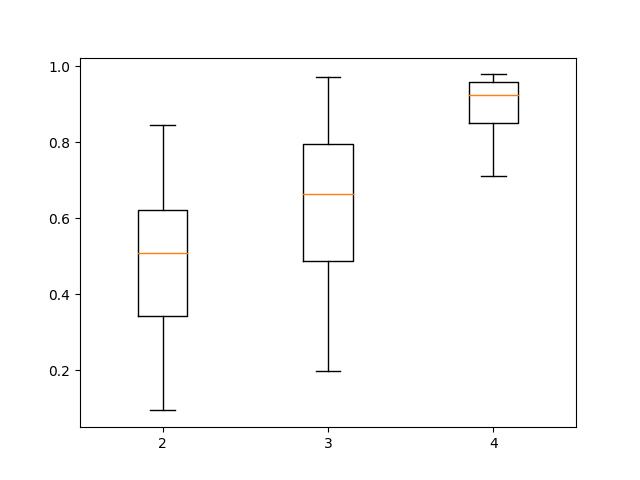

```python
plt.figure()
boxdata = []
xpos= []
for gpsize, dc in virt_dutycyles.items():
    boxdata.append(dc)
    xpos.append(gpsize)
plt.boxplot(boxdata, positions=xpos);
```

### The effect of signal threshold on the duty cycle calculations

Let's now run the duty cycle comparisons with 2 different signal threshold. The first threshold will be 10dB more than the silent audio and the second threshold is 20dB more.

```python
dutycyles_by_threshold = {}
for threshold in [-47, -37]:
    virt_dutycyles = calculate_dutycycle_by_groupsize(virtual_bynumbats,
                                                  'actual_virtual_filenames',
                                                  threshold,'../annotation_audio_analysis/virtual_multi_bat_audio/',
                                                 groupsizes=[4,3,2])
    obs_dutycyles = calculate_dutycycle_by_groupsize(bynumbats,
                                                     'hp_filenames',
                                                     threshold,
                                                     '../individual_call_analysis/hp_annotation_audio/')
    dutycyles_by_threshold[threshold] = [obs_dutycyles, virt_dutycyles]
```

[output not shown]

[output cut: 2001 more lines]

[output not shown]

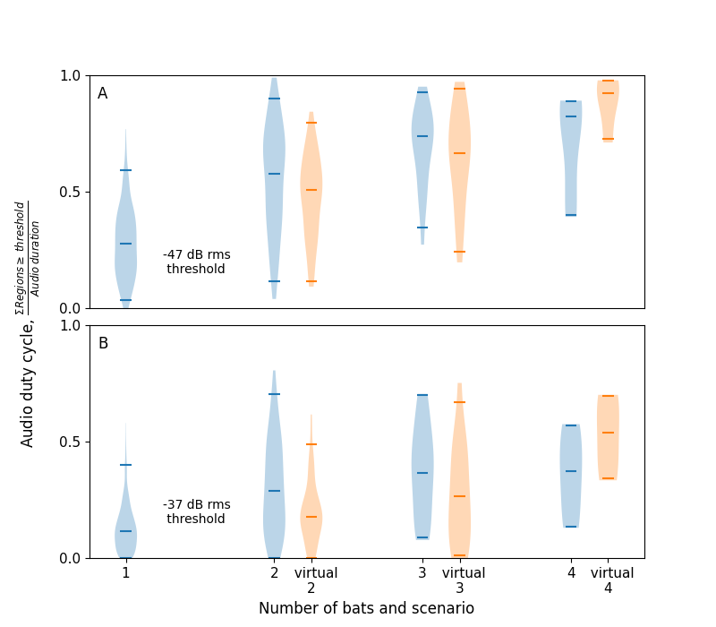

```python
plt.figure(figsize=(8,7))
a0 = plt.subplot(111)

a1 = plt.subplot(211)
plt.violinplot([dutycyles_by_threshold[-47][0][each] for each in [1,2,3,4]], positions=[1,2,3,4],widths=0.15,
               showextrema=False, quantiles=[[0.025,0.5,0.975]]*4)
plt.violinplot([dutycyles_by_threshold[-47][1][each] for each in [2,3,4]], positions=np.array([2,3,4])+0.25,
           widths=0.15, showextrema=False, quantiles=[[0.025,0.5,0.975]]*3)
plt.xticks([])
plt.ylim(0,1)
plt.text(1.25, 0.15,'-47 dB rms \n threshold')
plt.yticks([0,0.5,1.0],fontsize=11)
plt.text(0.015, 0.90, 'A', transform=a1.transAxes, fontsize=12)

a2 = plt.subplot(212)
plt.violinplot([dutycyles_by_threshold[-37][0][each] for each in [1,2,3,4]], positions=[1,2,3,4],widths=0.15,
              showextrema=False, quantiles=[[0.025,0.5,0.975]]*4)
plt.violinplot([dutycyles_by_threshold[-37][1][each] for each in [2,3,4]], positions=np.array([2,3,4])+0.25,
                           widths=0.15,showextrema=False, quantiles=[[0.025,0.5,0.975]]*3)
plt.text(1.25, 0.15,'-37 dB rms \n threshold')
plt.xlabel('Number of bats and scenario', fontsize=12)
plt.ylim(0,1)
plt.xticks([1,2,2.25,3,3.25,4,4.25],['1','2','  virtual\n2','3','  virtual\n3','4','  virtual\n4'],  fontsize=11)
plt.figtext(.02,0.3,'Audio duty cycle, $ \\frac{\Sigma Regions \geq \:threshold}{Audio \:duration}$',
            rotation='vertical', fontsize=12)
plt.yticks([0,0.5,1.0],fontsize=11);
plt.text(0.015, 0.90, 'B', transform=a2.transAxes, fontsize=12)
plt.subplots_adjust(wspace=None, hspace=0.07)
```

**Figure caption**: *The audio duty cycle, defined as the fraction of time occupied by calls in an audio recording across group sizes in observed and virtual multi-bat audio. The duty cycle was calculated across group sizes using two thresholds to detect calls. A) The duty cycle across group size in observed and virtual audio with the liberal threshold (-47 dBrms) set at +10dBrms above the background level B) Duty cycle across observed and virtual audio with a conservative threshold (-37 dBrms) set at +20 dB rms above the background level. Virtual multi-bat audio was created by adding duration-matched single bat audio files. Both A) and B) show a similar trend with a general increased duty cycle in multi-bat comparison to single bat audio. The 95 percentile ranges of duty cycles in observed and virtual audio overlap across group sizes 2-4. This overlap indicates that bats may not decreasing or increasing their call duty cycle in the presence of others.*

### Are the call duties much higher than expected by chance from single bat call duties?

If the bats are indeed not showing drastic responses (increased or decreased) to each other, the duty cycles should be broadly the same as calculated from assuming single bat duty cycles hold

```python
# get median duty cycles:
data37db = [dutycyles_by_threshold[-37][0][each] for each in [1,2,3,4]]
obs_medianDC = [np.median(each) for each in data37db]
obs_medianDC
```

```
[0.11364663865546218,
 0.28811511627906977,
 0.36457667197452226,
 0.37376466666666663]
```

```python
## The 2 bat case

def calc_prob_nonexclusive_events(probs):
    '''
    Calculates the probability of co-occurence of multiple non-mutually exclusive events.

    Parameters
    ----------
    probs : list/array-like
        All values must be between 0-1. Each probability value corresponds to the
        probability of one event type occuring.


    '''
    if len(probs)==2:
        A,B = probs
        return A + B - A*B
    elif len(probs) == 3:
        A,B,C = probs
        return A + B + C - A*B - B*C - A*C + A*B*C
    else:
        raise ValueError('0 or 4 events not supported')
```

```python
# Calculate the theoretically expected duty cycle if single bats were behaving independently
for repeats in [2,3]:
    print(calc_prob_nonexclusive_events([obs_medianDC[0]]*repeats))
```

```
0.21437771883323917
0.3036610503406778
```

## Two lines of evidence suggest no change in call duty in the presence of conspecifics

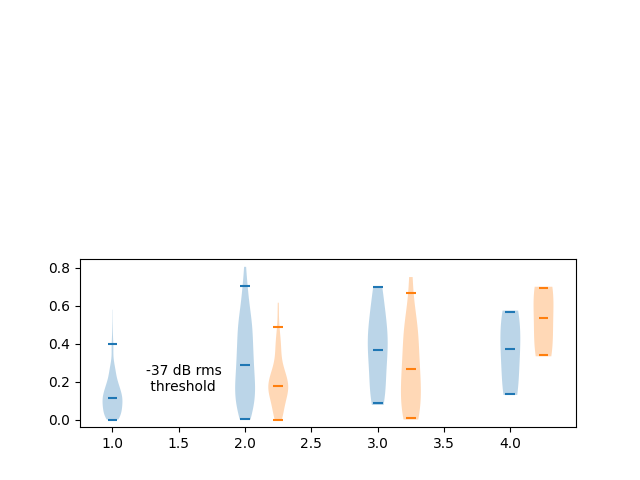

```python
plt.figure()
plt.violinplot([dutycyles_by_threshold[-47][0][each] for each in [1,2,3,4]], positions=[1,2,3,4],widths=0.15,
               showextrema=False, quantiles=[[0.025,0.5,0.975]]*4)
plt.violinplot([dutycyles_by_threshold[-47][1][each] for each in [2,3,4]], positions=np.array([2,3,4])+0.25,
           widths=0.15, showextrema=False, quantiles=[[0.025,0.5,0.975]]*3)
plt.xticks([])
plt.ylim(0,1)
plt.text(1.25, 0.15,'-47 dB rms \n threshold')
plt.yticks([0,0.5,1.0],fontsize=11)
plt.text(0.015, 0.90, 'A', transform=a1.transAxes, fontsize=12)

a2 = plt.subplot(212)
plt.violinplot([dutycyles_by_threshold[-37][0][each] for each in [1,2,3,4]], positions=[1,2,3,4],widths=0.15,
              showextrema=False, quantiles=[[0.025,0.5,0.975]]*4)
plt.violinplot([dutycyles_by_threshold[-37][1][each] for each in [2,3,4]], positions=np.array([2,3,4])+0.25,
                           widths=0.15,showextrema=False, quantiles=[[0.025,0.5,0.975]]*3)
plt.text(1.25, 0.15,'-37 dB rms \n threshold')
```

```python
# observed data
obs_dataset = []

for threshold in [-37, -47]:
    for groupsize in [1,2,3,4]:
        obs_dutycycle = dutycyles_by_threshold[threshold][0][groupsize]
        gpsize = np.tile(groupsize, len(obs_dutycycle))
        scenario = np.tile('obs', len(obs_dutycycle))
        df = pd.DataFrame(data={'groupsize':gpsize,
                                'duty_cycle':obs_dutycycle,
                                'audio_type': scenario})
        df['threshold_dbrms'] = threshold
        obs_dataset.append(df)

obs_dataset = pd.concat(obs_dataset)

# virtual audio data
virt_dataset = []

for threshold in [-37, -47]:
    for groupsize in [2,3,4]:
        obs_dutycycle = dutycyles_by_threshold[threshold][1][groupsize]
        gpsize = np.tile(groupsize, len(obs_dutycycle))
        scenario = np.tile('virtual', len(obs_dutycycle))
        df = pd.DataFrame(data={'groupsize':gpsize,
                                'duty_cycle':obs_dutycycle,
                                'audio_type': scenario})
        df['threshold_dbrms'] = threshold
        virt_dataset.append(df)

virt_dataset = pd.concat(virt_dataset)
```

```python
virt_and_obs_data = pd.concat([obs_dataset, virt_dataset])
```

```python
import seaborn as sns
```

```python
virt_and_obs_data
```

|  | groupsize | duty_cycle | audio_type | threshold_dbrms |
| --- | --- | --- | --- | --- |
| 0 | 1 | 0.094458 | obs | -37 |
| 1 | 1 | 0.179518 | obs | -37 |
| 2 | 1 | 0.130107 | obs | -37 |
| 3 | 1 | 0.083832 | obs | -37 |
| 4 | 1 | 0.125673 | obs | -37 |
| ... | ... | ... | ... | ... |
| 16 | 3 | 0.858858 | virtual | -47 |
| 0 | 4 | 0.711735 | virtual | -47 |
| 1 | 4 | 0.978063 | virtual | -47 |
| 2 | 4 | 0.895604 | virtual | -47 |
| 3 | 4 | 0.951276 | virtual | -47 |

1020 rows × 4 columns

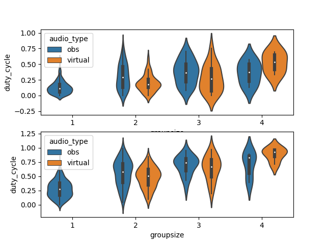

```python
# just checking that the dataframe shows the same patterns as the dictionaries - and that nothing has changed
# in between
plt.figure()
a0 = plt.subplot(211)
sns.violinplot(y='duty_cycle',x='groupsize', hue='audio_type',
               data=virt_and_obs_data[virt_and_obs_data['threshold_dbrms']==-37])
a1 = plt.subplot(212)
sns.violinplot(y='duty_cycle',x='groupsize', hue='audio_type',
               data=virt_and_obs_data[virt_and_obs_data['threshold_dbrms']==-47])
```

```python
virt_and_obs_data.to_csv('groupsizevsdutycyle_obsandvirt.csv')
```

```python
print(f'Notebook run ended at : {dt.datetime.now()}')
```

```
Notebook run ended at : 2020-11-29 19:38:10.057265
```